# Predictive Text Modelling: Exploratory Data Analysis and Milestone Report

Hedley Stirrat

04/07/2020

## Introduction

The aim of this project is to build a predictive text model. Given a series of words forming part of a sentence, the model should predict the next word.

The training and testing data were pulled from three sources: Twitter, news websites and blog websites. This report outlines the data import and cleaning steps, along with an exploratory data analysis of the available data.

## Data import

Data were downloaded from [the repository](https://d396qusza40orc.cloudfront.net/dsscapstone/dataset/Coursera-SwiftKey.zip) (17 June 2020), and extracted into a working directory. The three .txt files were read into R. The blogs dataset was the smallest with just under 900,000 observations, while the Twitter dataset was the largest with over two million observations.

```r
library(readr)
library(dplyr)
library(knitr)
library(ggplot2)
library(stringi)
library(stringr)
library(helprs) # install.github("heds1/helprs")
library(quanteda)
quanteda_options(threads = 16)

base_dir <- "C:/Users/hls/code/datasciencecoursera/capstone/"

dat_twitter <- data.frame(
    Text = read_lines(paste0(base_dir, "/data/en_US.twitter.txt")),
    Source = "twitter")
dat_blogs <- data.frame(
    Text = read_lines(paste0(base_dir, "/data/en_US.blogs.txt")),
    Source = "blogs")
dat_news <- data.frame(
    Text = read_lines(paste0(base_dir, "/data/en_US.news.txt")),
    Source = "news")

nrow(dat_twitter)
```

```
## [1] 2360148
```

```r
nrow(dat_blogs)
```

```
## [1] 899288
```

```r
nrow(dat_news)
```

```
## [1] 1010242
```

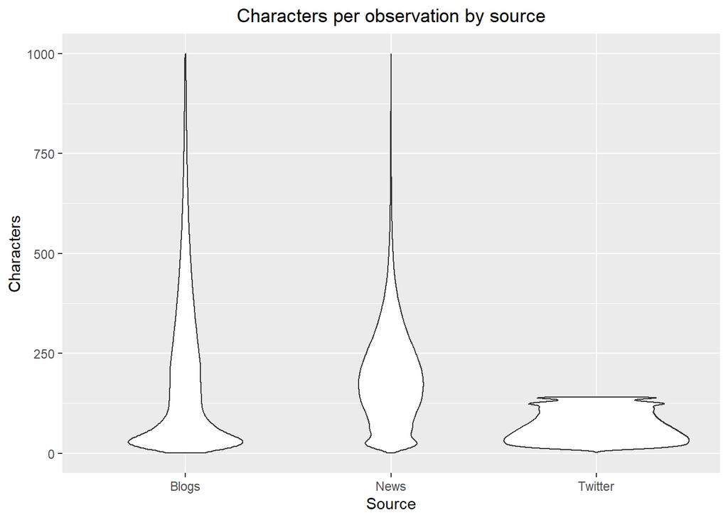

```r
bind_rows(
    data.frame(
        Characters = unlist(lapply(dat_twitter$Text, nchar)),
        Source = "Twitter"),
    data.frame(
        Characters = unlist(lapply(dat_blogs$Text, nchar)),
        Source = "Blogs"),
    data.frame(
        Characters = unlist(lapply(dat_news$Text, nchar)),
        Source = "News")) %>%
    ggplot(aes(x = Source, y = Characters)) +
        geom_violin() +
        ylim(0, 1000) +
        ggtitle("Characters per observation by source") +
        theme(plot.title = element_text(hjust = 0.5))
```

To keep memory usage within usable limits, a random sample of 100,000 observations was taken from each dataset and combined to form the working dataset.

```r
df <- bind_rows(
    dat_twitter %>%
        slice_sample(n = 100000),
    dat_blogs %>%
        slice_sample(n = 100000),
    dat_news %>%
        slice_sample(n = 100000))

rm(dat_twitter, dat_blogs, dat_news)
```

## Data cleaning

Before subsampling, the combined dataset comprised over four million rows, each row corresponding to a single observation (that is, a tweet, a blog entry or a news article).

A random selection of 10 rows of data are displayed below. It’s clear that the data are drawn from a wide swath of the internet and will require several cleaning steps to reach a state from which a predictive text model will be able to be founded on.

```r
kable(slice_sample(df, n = 10))
```

| Text | Source |
| --- | --- |
| Should I? No. I’m going back to bed. | twitter |
| Lane One westbound will be closed from 9 a.m. until 3 p.m. Monday through Friday, | news |
| For the egg patterns, I cheated a bit using Sally Hansen nail polish pens. In reading the instructions, you can easily wash off the pen design if you make a mistake using luke warm water. When satisfi… | blogs |
| I thought we told each other everything. apparently not… | twitter |
| We need to record a 1 year long song | twitter |
| Prolly don’t matter but happy birthday man | twitter |
| “We live in the community. We work in the community. We should help to improve the community,” Pointer said at the cleanup. | news |
| If they wanna be with me or not.. :( | twitter |
| But when will you, Greg? When? | news |
| Alright, ready for the tour? | blogs |

The initial data cleaning comprised the following actions:

- convert all characters to lowercase
- convert non-ASCII characters where possible
- remove URLs with regex, including `https`-style URLs, `bit.ly`-style URLs, and simple URLs containing `.com`.
- remove extra whitespace

```r
df <- df %>%
    # convert all to lowercase
    mutate(Text = tolower(Text)) %>%

    # convert non-ascii chr
    mutate(Text = stri_trans_general(Text, "latin-ascii")) %>%

    # remove URLs
    mutate(Text = gsub("\\s?(http)\\S*\\s?", " ", Text, ignore.case = TRUE)) %>%

    # remove .com (sometimes no URL is given)
    mutate(Text = gsub("\\s?\\S*(.com)\\S*\\s?", " ", Text, ignore.case = TRUE)) %>%

    # remove bit.ly URLs
    mutate(Text = gsub("\\s?\\S*(bit.ly)\\S*\\s?", " ", Text, ignore.case = TRUE)) %>%

    # remove extra whitespace
    mutate(Text = gsub("\\s+", " ", Text))
```

After this initial cleaning, the data were split into training and testing sets with a ratio of 3:1, and written out as csv files for subsequent data exploration and model building.

```r
split_data <- df %>%
    split_sets(props = c(0.75, 0.25))

glimpse(split_data[['train']])
```

```
## Rows: 224,979
## Columns: 2
## $ Text   <chr> "thanks for following! :d", "had a splender on her ass lol h...
## $ Source <chr> "twitter", "twitter", "twitter", "twitter", "twitter", "twit...
```

```r
glimpse(split_data[['test']])
```

```
## Rows: 75,021
## Columns: 2
## $ Text   <chr> "living in the home depicted in &#39;american gothic&#39; pa...
## $ Source <chr> "twitter", "twitter", "twitter", "twitter", "twitter", "twit...
```

```r
write.csv(split_data[['train']], paste0(base_dir, "data/training-cleaned.csv"), row.names = FALSE)

write.csv(split_data[['test']], paste0(base_dir, "data/testing-cleaned.csv"), row.names = FALSE)

rm(df)
```

The training and testing datasets, therefore, comprised approximately 225,000 and 75,000 observations, respectively.

## Further exploration and text analysis

The quanteda R package was used for textual analysis. Initial data exploration was conducted on the training dataset. The training corpus was created, and the head of the summary of the resulting corpus is shown below. Each observation contained several types, split into several tokens comprising at least one sentence. The observation source (Twitter, news or blog) was also brought through.

```r
training_corpus <- corpus(split_data[['train']], text_field = 'Text')

kable(head(summary(training_corpus)))
```

| Text | Types | Tokens | Sentences | Source |
| --- | --- | --- | --- | --- |
| text1 | 6 | 6 | 1 | twitter |
| text2 | 11 | 12 | 1 | twitter |
| text3 | 12 | 15 | 1 | twitter |
| text4 | 8 | 8 | 1 | twitter |
| text5 | 18 | 18 | 1 | twitter |
| text6 | 18 | 28 | 1 | twitter |

Following this, tokens were created from the training corpus. A series of data-cleaning parameters were applied to the tokenisation function, including `remove_numbers = TRUE`, `remove_punct = TRUE`, `remove_symbols = TRUE`, `remove_url = TRUE` and `split_hyphens = TRUE`.

```r
training_tokens <- tokens(training_corpus,
    remove_numbers = TRUE,
    remove_punct = TRUE,
    remove_symbols = TRUE,
    remove_url = TRUE,
    what = "word",
    split_hyphens = TRUE,
    include_docvars = TRUE)
```

```r
dfm_list <- list()

for (i in 1:5) {

    # generate ngrams of length i
    these_ngrams <- tokens_ngrams(training_tokens, i)

    # construct dfm, setting stem to false as input will not be stemmed
    this_dfm <- dfm(these_ngrams, tolower = TRUE, stem = FALSE)

    # trim dfm by removing ngrams appearing fewer than 3 times
    this_dfm_trimmed <- dfm_trim(this_dfm,
        min_termfreq = 3,
        termfreq_type = "count")

    # append to dfm_list
    dfm_list[[i]] <- this_dfm_trimmed

    # clear env
    rm(these_ngrams, this_dfm, this_dfm_trimmed)

}

head(dfm_list[[1]])
```

```
## Document-feature matrix of: 6 documents, 51,367 features (100.0% sparse) and 1 docvar.
##        features
## docs    thanks for following d had a on her ass lol
##   text1      1   1         1 1   0 0  0   0   0   0
##   text2      0   0         0 0   1 1  1   2   1   1
##   text3      0   0         0 0   0 0  0   0   0   0
##   text4      0   0         0 0   0 0  0   0   0   0
##   text5      0   1         0 0   0 0  0   0   0   0
##   text6      0   0         0 0   0 4  0   0   0   0
## [ reached max_nfeat ... 51,357 more features ]
```

To get a quick idea of the distribution of words, we can use the DFM for the tokens where n = 1. There are approximately 50,000 words identified. We extract all words and their counts, group by count, and get an idea of the distribution of words in the dataset.

```r
length(dfm_list[[1]]@Dimnames$features)
```

```
## [1] 51367
```

```r
# get all word counts
words <- topfeatures(dfm_list[[1]], length(dfm_list[[1]]))

words_df <- data.frame(
    Word = names(words),
    NumWordAppearances = words) %>%
    group_by(NumWordAppearances) %>%
    summarise(Frequency = n())
head(words_df)
```

```
## # A tibble: 6 x 2
##   NumWordAppearances Frequency
##                <dbl>     <int>
## 1                  3      8715
## 2                  4      5467
## 3                  5      3918
## 4                  6      2955
## 5                  7      2330
## 6                  8      1916
```

```r
tail(words_df)
```

```
## # A tibble: 6 x 2
##   NumWordAppearances Frequency
##                <dbl>     <int>
## 1             112113         1
## 2             141486         1
## 3             158001         1
## 4             170350         1
## 5             179275         1
## 6             328006         1
```

```r
rm(words)
```

We can see that words that appear only three times (the minimum, given our data trimming) appear the most, followed by words that appear only four times, and so on. Conversely, words that appear several times (typical stop words such as “the”, “a”, etc.) have unique frequencies as their appearances rise to very high numbers.

To explore this further, we obtain the top twenty words from the unigram DFM. We divide these numbers by the total number of observations to get an idea of the proportion of observations that these top words are found in:

```r
unigram_top_twenty <- topfeatures(dfm_list[[1]], 20)

kable(data.frame(
    Word = names(unigram_top_twenty),
    AppearancesPerObservation = unigram_top_twenty / length(dfm_list[[1]]@Dimnames$docs),
    row.names = NULL))
```

| Word | AppearancesPerObservation |
| --- | --- |
| the | 1.4579405 |
| to | 0.7968522 |
| and | 0.7571818 |
| a | 0.7022922 |
| of | 0.6288854 |
| in | 0.4983265 |
| i | 0.4422457 |
| that | 0.3188920 |
| for | 0.3030594 |
| is | 0.3019348 |
| it | 0.2615977 |
| on | 0.2284035 |
| you | 0.2188693 |
| with | 0.2140822 |
| was | 0.1924713 |
| at | 0.1582548 |
| this | 0.1573836 |
| my | 0.1567702 |
| as | 0.1549078 |
| be | 0.1540722 |

```r
rm(unigram_top_twenty)
```

On average, “the” appears about 1.5 times per document; “to” appears about 0.8 times per document; and so on.

We then checked the number of n-grams for n = 1–5. The highest number of n-grams were found for n = 2 and n = 3, while frequency dropped off significantly for n = 4 and n = 5.

```r
for (i in 1:5) {

    this_dfm <- dfm_list[[i]]

    this_summary_df <- data.frame(
        NgramLength = i,
        NumberOfInstances = length(dfm_list[[i]]@Dimnames$features))

    # append summary to single df
    if (!exists('dfm_length_summary')) {
        dfm_length_summary <- this_summary_df
    } else {
        dfm_length_summary <- bind_rows(dfm_length_summary, this_summary_df)
    }
}

kable(dfm_length_summary)
```

| NgramLength | NumberOfInstances |
| --- | --- |
| 1 | 51367 |
| 2 | 270831 |
| 3 | 217152 |
| 4 | 69708 |
| 5 | 14554 |

To explore further the document-frequency matrices for n-grams of length 2–5, the 10 top features from each DFM were extracted:

```r
for (i in 2:5) {

    this_dfm <- dfm_list[[i]]

    # construct summary dataframe listing the top ten ngrams for length i
    this_summary_df <- data.frame(
        Ngram = names(topfeatures(this_dfm, 10)),
        Count = topfeatures(this_dfm, 10),
        Length = i)

    # append summary to single df
    if (!exists('dfm_summary')) {
        dfm_summary <- this_summary_df
    } else {
        dfm_summary <- bind_rows(dfm_summary, this_summary_df)
    }

}
```

The 10 top features from each DFM are plotted below. It should be noted that stopwords have not been removed from the tokens, so those short, common words are reflected strongly in the summary plots. Since the input will not be sanitised of these words, the model should not remove them either.

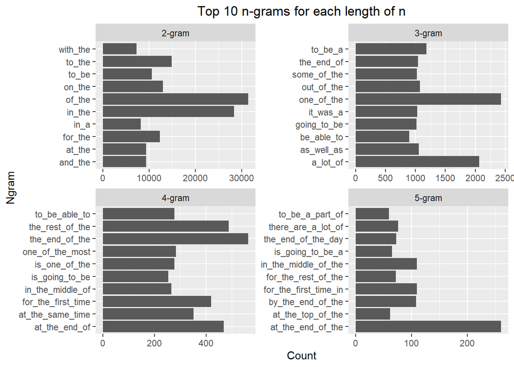

```r
dfm_summary %>%
    mutate(Length = paste0(Length, "-gram")) %>%
    ggplot(aes(x = Ngram, y = Count)) +
        geom_col() +
        coord_flip() +
        facet_wrap(~ Length, scales = "free") +
        ggtitle("Top 10 n-grams for each length of n") +
        theme(plot.title = element_text(hjust = 0.5))
```

Using a similar strategy to the one above, we can estimate how many words we need in our dictionary to cover x% of all word use instances based on the training set. Firstly, we construct a single dataframe containing all the unigram instances (words) in our training data. We can summarise this by comparing the number of unique words to the total number of words identified. From this, we see that our approximately 50,000 unique words appear over six million times in the training dataset:

```r
# get all word counts
words <- topfeatures(dfm_list[[1]], length(dfm_list[[1]]))

words_df <- data.frame(
    Word = names(words),
    NumWordAppearances = words)

unique_words_summary <- words_df %>%
    summarise(
        UniqueWords = nrow(words_df),
        TotalNumWords = sum(NumWordAppearances))

unique_words_summary
```

```
##   UniqueWords TotalNumWords
## 1       51367       6370018
```

```r
words_df %>%
    mutate(CumulativeCoverage = cumsum(NumWordAppearances)) %>%
    filter(CumulativeCoverage < unique_words_summary$TotalNumWords / 2) %>%
    nrow(.)
```

```
## [1] 128
```

Our most frequent 128 words will cover 50% of all word instances in the training dataset.

```r
words_df %>%
    mutate(CumulativeCoverage = cumsum(NumWordAppearances)) %>%
    filter(CumulativeCoverage < unique_words_summary$TotalNumWords * .9) %>%
    nrow(.)
```

```
## [1] 6203
```

Note that these numbers would probably increase slightly if larger samples of the original datasets were obtained, as more unique words would likely be present in larger datasets. However, we need to operate under low-memory-load conditions, so the above analysis is considered appropriate for this use case.

## Building a predictive model

In order to supply word predictions, we need a way of splitting up the n-grams into heads and tails; that is, the head is the word (or words) that comprise the beginning of the n-gram, and the tail is the final word (which forms the basis of prediction). In order to retrieve heads and tails for each n-gram, we define two functions: `get_head` and `get_tail`, which split a character vector of length n (where n = number of words in n-gram) and retrieve the appropriate elements.

```r
get_head <- function(x) {

        # get number of words in ngram
    num_words <- length(x)

    # every word but the last is the head--get number of head words
    num_heads <- num_words - 1

    # instantiate vector of head words
    this_head <- c()

    # gather all head words
    for (i in 1:num_heads) {
        this_head <- c(this_head, x[[i]])
    }

    return(paste(this_head, collapse = " "))
}

get_tail <- function(x) {

    # get number of words in ngram
    num_words <- length(x)

    # return the final word (the predicted word)
    return(paste(x[[num_words]], collapse = " "))
}
```

Next, we loop over our DFM list for each n-gram from n = 2–5, using `get_head` and `get_tail` to extract the relevant parts of the n-grams. From these, we create a dataframe containing variables Head (for the words comprising the head), Tail (for the predicted word), Count (for frequency that this n-gram appeared in the training data) and Length (for n, i.e., length of n-gram):

```r
if (exists('feature_count_list')) rm(feature_count_list)
feature_count_list <- list()

if (exists('dfm_summary')) rm(dfm_summary)

for (i in 2:5) {

    # get ngram counts
    ngrams <- topfeatures(dfm_list[[i]], n = length(dfm_list[[i]]@Dimnames$features))

    # split ngrams up into words
    ngrams_split <- str_split(names(ngrams), "_")

    # get heads
    my_heads <- unlist(lapply(ngrams_split, get_head))

    # get tails
    my_tails <- unlist(lapply(ngrams_split, get_tail))

    # create df of heads, tails and counts
    ngrams_split_df <- data.frame(
        Head = my_heads,
        Tail = my_tails,
        Count = ngrams,
        Length = i,
        check.names = FALSE)

    # append to master dataframe
    if (!exists("ngrams_reference")) {
        ngrams_reference <- ngrams_split_df
    } else {
        ngrams_reference <- bind_rows(ngrams_reference, ngrams_split_df)
    }
}

# write so we don't have to do this again
# write.csv(ngrams_reference, paste0(base_dir, "data/ngrams-reference.csv"), row.names = FALSE)
```

Data were then subjected to add-one smoothing (where 1 is added to every word instance count).

```r
ngrams_reference <- ngrams_reference %>%
    mutate(Count = Count + 1)
```

Minimal pre-processing of user input will be conducted. To prepare the input for word prediction, the following `prepare_input` function is used. This function returns a list of outputs, including the verbatim text input, the text input split into constituent words (for head/tail assignment), and the number of words in the input (to select the appropriate n-gram dictionary to query in the first instance).

```r
# prepare input for prediction
prepare_input <- function(input) {

    input <- tolower(input)

    # split by spaces into constituent words
    split_input <- str_split(input, " ")

    # get number of words in input
    num_words <- length(split_input[[1]])

    # get total string
    complete_input <- paste(unlist(split_input),collapse = " ")

    # return list of outputs
    return(list(
        complete_input = complete_input,
        split_input = split_input,
        num_words = num_words)
    )

}
```

Model prediction is conducted with the `get_hits` function. This simple approach takes an input argument that is the output of `prepare_input`. The constituent words of the input head are looked up in the reference dictionary for direct head matches. If more than four matches are found, the matches are sorted according to frequency of occurrence in the training data, with the most frequent word prediction forming the recommended word. If less than five hits are discovered, we reduce the n-gram length by 1, and query the reference dictionary again.

For example, with the user input “thank you so much”, `prepare_input` splits each word up, and recognises four words in the input. The first check of `get_hits` searches the reference dictionary for an exact match for “thank you so much”. If fewer than five exact matches are found, we strip off the first word in the input. This gives us “you so much”, a tri-gram. We then search the reference dictionary for this tri-gram. If fewer than five cumulative hits are found at this point, we then search for “so much”.

This process continues until either a) we have five hits, or b) we have run out of possible n-gram references.

```r
# predict
get_hits <- function(input) {

    hits_df <- ngrams_reference %>%
        filter(Head == input$complete_input)

    # instantiate vector of hits to return
    hits_for_return <- c()

    # check for complete match first, returning top 5 matches
    if (nrow(hits_df) > 0) {

        hits_df <- hits_df %>%
            arrange(desc(Count))

        # get predicted word(s)
        hits_vector <- hits_df$Tail

        hits_for_return <- c(hits_for_return, hits_vector)

        # if we have five matches, return
        if (length(hits_for_return) > 4) {
            return(hits_for_return[1:5])
        }

    }
    # if we have got to this point, we haven't got five matches! so let's check
    # shorter ngrams

    # get first word to construct ngram out of--start from 2 because the first
    # attempt starts from 1
    first_word_num <- 2

    # repeat until we have five hits
    while(nrow(hits_df) < 5) {

        # get all word indices except for first word
        word_indices <- first_word_num:input$num_words

        # instantiate word string
        words <- c()

        # get all words
        for (word in word_indices) {
            words <- c(words, input$split_input[[1]][[word]])
        }

        # collapse into single string
        words <- paste(words, collapse = " ")

        # look for matches
        hits_df <- ngrams_reference %>%
            filter(Head == words)

        # return hits if there are any
        if (nrow(hits_df) > 0) {

            hits_df <- hits_df %>%
                arrange(desc(Count))

            # get predicted word(s)
            hits_vector <- hits_df$Tail

            # concatenate these onto original hits
            hits_for_return <- c(hits_for_return, hits_vector)

            # remove duplicates
            hits_for_return <- hits_for_return[!duplicated(hits_for_return)]

            if (length(hits_for_return) > 4) {
                return(hits_for_return[1:5])
            }

        }

        # if we've tried all available ngrams, return (otherwise our while
        # loop will keep running!)
        if (first_word_num == 4) {
            return(hits_for_return)
        }

        # otherwise, increment to start looking at next word and repeat
        # (i.e., look for a shorter ngram)
        first_word_num <- first_word_num + 1

    }
}
```

Finally, we create a function that calls both `prepare_input` and `get_hits`. `predict_word` takes a user input and returns the word recommendation.

```r
predict_word <- function(provided_string) {
    cleaned_input <- prepare_input(provided_string)
    get_hits(cleaned_input)
}
```

Let’s run the example above; five matches are returned, with the most probable deemed the first match (the one with the highest count for the highest-order n-gram). In this case, our predicted word is “for”:

```r
predict_word("thank you so much")
```

```
## [1] "for"    "to"     "i"      "please" "it's"
```

Another example:

```r
predict_word("how are you")
```

```
## [1] "doing" "going" "today" "guys"  "d"
```

## Model evaluation

The preliminary model was evaluated by reading in the testing data, and transforming it with the same quanteda workflow as described for the training data. In short, this included creating the corpus and tokenisation.

```r
testing <- read.csv(paste0(base_dir, "data/testing-cleaned.csv"))

testing_corpus <- corpus(testing, text_field = 'Text')

testing_tokens <- tokens(testing_corpus,
    remove_numbers = TRUE,
    remove_punct = TRUE,
    remove_symbols = TRUE,
    remove_url = TRUE,
    what = "word",
    split_hyphens = TRUE,
    include_docvars = TRUE)
```

Two testing parameters were defined. `successful_top_prediction` counts the instances where the top predicted word matched the actual word, while `successful_top_five_prediction` counts the instances where the actual word was found in the top five predicted words.

The tokens were tested in the context of each sentence. Sentences must be at least five words long, as the first predicted word was the fifth in the sentence, and the predictors were the first four words. Following each test, 1 was added to each word index, meaning the predicted word was word six, and the predictors were words 2–5.

One hundred random tokens were selected from the testing set, and the test below was run. Note that no seed was set, so that further iterations of the model are not evaluated against the same test set to reduce the chance of overfitting the model.

```r
successful_top_prediction <- c()
successful_top_five_prediction <- c()

for (i in sample(1:length(testing_tokens), 100)) {

    # get document
    this_document <- testing_tokens[i][[1]]

    # get number of words in doc
    num_words <- length(this_document)

    # instantiate start and end words
    start_index <- 1
    end_index <- 4
    predict_index <- 5

    # test until the predicted word is the last word in the doc
    while(predict_index <= num_words) {

        this_head <- paste(this_document[start_index:end_index], collapse = " ")
        this_prediction <- predict_word(this_head)
        actual_word <- this_document[predict_index]
        successful_top_prediction <- c(
            successful_top_prediction, ifelse(this_prediction[1] == actual_word, TRUE, FALSE)
        )
        successful_top_five_prediction <- c(
            successful_top_five_prediction, ifelse(actual_word %in% this_prediction, TRUE, FALSE)
        )

        start_index <- start_index + 1
        end_index <- end_index + 1
        predict_index <- predict_index + 1
    }
}
```

The results are displayed below. As expected, the actual word was predicted more reliably when including the top five suggestions, and less reliably when only the top selection was put forward. The results of the top-one prediction are displayed below, showing that the correct word was predicted 17% of the time:

```r
top_pred_results <- data.frame(
    SuccessfulCount = sum(successful_top_prediction),
    UnsuccessfulCount = length(successful_top_prediction) - sum(successful_top_prediction),
    SuccessfulPercent = round(sum(successful_top_prediction) / length(successful_top_prediction) * 100, 1)
)

kable(top_pred_results)
```

| SuccessfulCount | UnsuccessfulCount | SuccessfulPercent |
| --- | --- | --- |
| 409 | 2044 | 16.7 |

The results of the top-five prediction are shown below, showing that the actual word was within the top five predicted words 30% of the time:

```r
top_five_pred_results <- data.frame(
    SuccessfulCount = sum(successful_top_five_prediction),
    UnsuccessfulCount = length(successful_top_five_prediction) - sum(successful_top_five_prediction),
    SuccessfulPercent = round(sum(successful_top_five_prediction) / length(successful_top_five_prediction) * 100, 1)
)

kable(top_five_pred_results)
```

[output not shown]